# Homework 9

Author

Nicole Friedl

Published

March 28, 2025

## Part 1: Interpretation of three-way interaction models

Park & Brannon (2013) developed a game to train children’s approximate number systems (ANS, a basic system for representing quantities identified in many animals) that positively affect children’s math achievement in primary school. It is also known that better math readiness (counting, number identification, simple addition skills, etc.) is associated with greater primary school math achievement. The investigators hypothesize that the interaction effect between ANS training and math readiness would vary by technology access, such that the ANS training method be more effective when the children have low math readiness only if the children do not have access to any other games at home.

**Codebook:**

- `ready`: A continuous math readiness score ranging, values: 10-60
- `hours`: Number of hours spent playing ANS training game
- `game`: 0 = other games at home, 1 = no other games at home
- `achieve`: Math achievement score ranging, values: 10-80

The investigators fit their model and obtained the following results:

Achieve = 50.94 + 0.163 * ready_c + 0.109 * hours_c - 1.620 * game - 0.019 * ready_c:hours_c + 0.255 * ready_c:game + 0.100 * hours_c:game - 0.013 * ready_c:hours_c:game

Provide the interpretation of each parameter estimate.

ready_c (0.163): The coefficient for ready_c indicates that, holding all other variables constant, for each 1-unit increase in math readiness (centered), the achievement score is expected to increase by 0.163 units. This suggests that higher math readiness, such as better counting, number identification, and addition skills, is positively associated with better achievement in the math task.

hours_c (0.109): The coefficient for hours_c indicates that, holding all other variables constant, for each 1-unit increase in the number of hours spent on training or learning, the achievement score is expected to increase by 0.109 units. This suggests that the more time spent training, the better the math achievement, which is consistent with the idea that time spent on learning contributes positively to math performance.

ready_c:hours_c (-0.019): The interaction term ready_c:hours_c represents the combined effect of math readiness and hours spent on achievement. The negative coefficient of -0.019 indicates that, as the number of hours spent on the task increases, the positive effect of math readiness on achievement slightly decreases. This could suggest that for children with higher readiness, spending more time may have a diminishing return on achievement, potentially due to other factors (such as fatigue or diminishing marginal benefits).

```r
options(conflicts.policy = "depends.ok")
library(tidyverse)
library(Matrix, exclude = c("expand", "pack", "unpack"))
library(lme4)
library(car, exclude = c("recode", "some"))
library(boot, exclude = c("logit"))
library(rmemore)
library(ggplot2)


path_data <- "homework/data"
```

## Part 2: Puppies

Researchers wanted to know whether the positive relationship between a puppy’s temperament and their ability to successfully socialize with other puppies is mediated by the rate at which they communicate playfulness (i.e., wag their tails). The researchers brought litters of puppies into their lab (magically, all the litters has 8 puppies in them). Each puppy was temperament tested and given a score ranging from 1 to 10 (1 = extremely shy, 10 = extremely outgoing). The researchers then observed the puppies playing for 1 hour and recorded each puppy’s TWPM (tail wag per minute) and the total amount of time they spent wrestling with other puppies (vs. not interacting with other puppies).

**Codebook:**

- `group`: The puppy’s litter, values: 1-100
- `temperament`: The individual puppy’s temperament score, values: 1 (extremely shy) - 10 (extremely outgoing)
- `twpm`: Puppy’s average tail wag per minute, values: 2.35-60.07
- `play`: Total amount of time the puppy spent playing with other puppies (in minutes), values: 0-54.60

##1. Read in and inspect the data

```r
d1 <- read_csv(here::here(path_data, "puppies.csv"), show_col_types = FALSE)

glimpse(d1)
```

```
Rows: 800
Columns: 4
$ group       <dbl> 1, 1, 1, 1, 1, 1, 1, 1, 2, 2, 2, 2, 2, 2, 2, 2, 3, 3, 3, 3…
$ temperament <dbl> 7.23, 6.97, 8.86, 4.85, 5.29, 7.31, 8.70, 9.48, 0.50, 2.02…
$ twpm        <dbl> 28.63, 30.23, 30.64, 32.88, 33.54, 34.38, 35.35, 42.66, 8.…
$ play        <dbl> 25.76, 23.69, 27.84, 21.21, 27.60, 26.17, 21.84, 31.03, 2.…
```

## 2. Create variables that are cluster means of temperament and twpm. Also cluster-mean center temperament and twpm.

```r
d1 <- d1 %>%
  group_by(group) %>%
  mutate(
    temperament_cluster_mean = mean(temperament, na.rm = TRUE),
    twpm_cluster_mean = mean(twpm, na.rm = TRUE),
    temperament_c = temperament - temperament_cluster_mean,
    twpm_c = twpm - twpm_cluster_mean
  ) %>%
  ungroup()

glimpse(d1)
```

```
Rows: 800
Columns: 8
$ group                    <dbl> 1, 1, 1, 1, 1, 1, 1, 1, 2, 2, 2, 2, 2, 2, 2, …
$ temperament              <dbl> 7.23, 6.97, 8.86, 4.85, 5.29, 7.31, 8.70, 9.4…
$ twpm                     <dbl> 28.63, 30.23, 30.64, 32.88, 33.54, 34.38, 35.…
$ play                     <dbl> 25.76, 23.69, 27.84, 21.21, 27.60, 26.17, 21.…
$ temperament_cluster_mean <dbl> 7.33625, 7.33625, 7.33625, 7.33625, 7.33625, …
$ twpm_cluster_mean        <dbl> 33.53875, 33.53875, 33.53875, 33.53875, 33.53…
$ temperament_c            <dbl> -0.10625, -0.36625, 1.52375, -2.48625, -2.046…
$ twpm_c                   <dbl> -4.90875, -3.30875, -2.89875, -0.65875, 0.001…
```

## 3. The researchers want to estimate the between-litter and the within-litter effects of temperament score on play time of the puppies. Create a plot with multiple panels, where each panel shows the relationship between temperament score and play time among puppies of a given litter. Run the LMEM model that would test the between-litter and the within-litter relationships. Interpret the fixed effects. What conclusions would you draw?

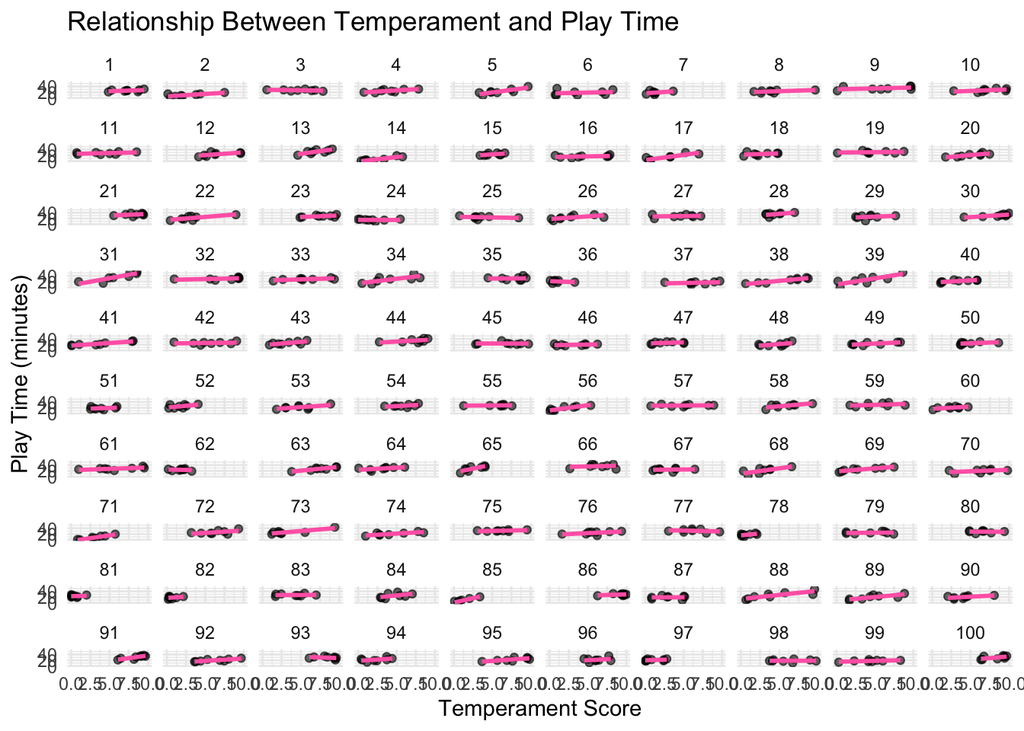

```r
ggplot(d1, aes(x = temperament, y = play)) +
  geom_point(alpha = 0.6) +
  geom_smooth(method = "lm", se = FALSE, color = "hotpink") +
  facet_wrap(~ group) +
  labs(
    title = "Relationship Between Temperament and Play Time",
    x = "Temperament Score",
    y = "Play Time (minutes)"
  ) +
  theme_minimal()
```

```r
m_1 <- lmer(play ~ temperament_c + temperament_cluster_mean + (1 | group), data = d1)

summary(m_1)
```

```
Linear mixed model fit by REML ['lmerMod']
Formula: play ~ temperament_c + temperament_cluster_mean + (1 | group)
   Data: d1

REML criterion at convergence: 5062.8

Scaled residuals:
    Min      1Q  Median      3Q     Max
-4.1127 -0.6203  0.0174  0.5852  3.8882

Random effects:
 Groups   Name        Variance Std.Dev.
 group    (Intercept) 20.54    4.532
 Residual             25.51    5.051
Number of obs: 800, groups:  group, 100

Fixed effects:
                         Estimate Std. Error t value
(Intercept)              16.92351    1.23311  13.724
temperament_c             1.46140    0.08984  16.266
temperament_cluster_mean  1.56297    0.24389   6.408

Correlation of Fixed Effects:
            (Intr) tmprm_
tempermnt_c  0.000
tmprmnt_cl_ -0.919  0.000
```

The results show that both within-litter and between-litter temperament effects significantly predict playtime. Puppies that are more outgoing than their littermates tend to play more (+1.46 min per temperament point), while litters with a higher average temperament score also have puppies that play more overall (+1.56 min per point). Both effects are highly significant (p < 0.001), suggesting that temperament influences play both at the individual and group level. The slightly stronger between-litter effect indicates that overall litter temperament plays a key role in social play behavior.

```r
# Does within-litter temperament predict TWPM? (Path A)

# Does TWPM predict playtime when controlling for temperament (Path B)

# Does temparament still predict playtime when controlling for TWPM (Path C')

m_a <- lmer(twpm ~ temperament_c + (1 | group), data = d1)
summary(m_a)
```

```
Linear mixed model fit by REML ['lmerMod']
Formula: twpm ~ temperament_c + (1 | group)
   Data: d1

REML criterion at convergence: 5220.3

Scaled residuals:
    Min      1Q  Median      3Q     Max
-3.3298 -0.6350  0.0047  0.5771  3.8155

Random effects:
 Groups   Name        Variance Std.Dev.
 group    (Intercept) 39.15    6.257
 Residual             29.39    5.421
Number of obs: 800, groups:  group, 100

Fixed effects:
              Estimate Std. Error t value
(Intercept)   29.88021    0.65439   45.66
temperament_c  1.52927    0.09643   15.86

Correlation of Fixed Effects:
            (Intr)
tempermnt_c 0.000
```

```r
path_a <- fixef(m_a)[2]

m_b <- lmer(play ~ temperament_c + twpm + (1 | group), data = d1)
summary(m_b)
```

```
Linear mixed model fit by REML ['lmerMod']
Formula: play ~ temperament_c + twpm + (1 | group)
   Data: d1

REML criterion at convergence: 4696.7

Scaled residuals:
    Min      1Q  Median      3Q     Max
-3.3400 -0.6029  0.0273  0.6104  3.6101

Random effects:
 Groups   Name        Variance Std.Dev.
 group    (Intercept) 10.85    3.293
 Residual             16.37    4.045
Number of obs: 800, groups:  group, 100

Fixed effects:
              Estimate Std. Error t value
(Intercept)    6.60052    0.83218   7.932
temperament_c  0.56152    0.08158   6.883
twpm           0.58843    0.02513  23.420

Correlation of Fixed Effects:
            (Intr) tmprm_
tempermnt_c  0.425
twpm        -0.902 -0.471
```

```r
path_b <- fixef(m_b)[3]

indirect.mlm <- function(data, indices, y, x, mediator, group.id, between.m, uncentered.x) {
  d <- data[indices, ]

indirect_effect <- path_a * path_b

  return(indirect_effect)
}

d1 <- as.data.frame(d1)
set.seed(111)
mediated_mlm <- boot(data = d1, statistic = indirect.mlm, R = 500, strata = d1$group,
                      y = "play", x = "temperament_c", mediator = "twpm", group.id = "group",
                      between.m = TRUE, uncentered.x = FALSE)

summary(mediated_mlm)
```

```
    R original bootBias bootSE bootMed
1 500  0.89988        0      0 0.89988
```

## Part 3: Dahlia Differentiation

Dahlias are a flowering plant native to Mexico and Central America. Dahlia societies have been formed in various communities to form connections among individuals who are enthusiastic about growing dahlias. Given the broad range and many varieties of dahlias, it can be difficult to differentiate dahlias from other non-dahlia flowers. To test whether dahlia society members can differentiate dahlias better than non-society members, you recruited 100 members of dahlia societies and 100 non-members to participate in an experiment. Participants complete a task in which they see photos of 200 flowers, 90 of them dahlia and 110 non-dahlia. Participants must respond to each photo whether it is a dahlia (“yes”) or not (“no”).

- `id`: Participant ID number, values: 1-200
- `trial`: Trial number in the task, values: 1-200
- `society`: Whether the participant is a dahlia society member or not, values: 0 = no, 1 = yes
- `flower_type`: Type of flower in the photo, values: 0 = not dahlia, 1 = dahlia
- `response`: Participants response, values: 0 = “no” (not dahlia), 1 = “yes” (dahlia)

## 1. Read in and inspect the data.

```r
d2 <- read_csv(here::here(path_data, "dahlia_sdt.csv"), show_col_types = FALSE)

glimpse(d2)
```

```
Rows: 80,000
Columns: 5
$ id          <dbl> 1, 1, 1, 1, 1, 1, 1, 1, 1, 1, 1, 1, 1, 1, 1, 1, 1, 1, 1, 1…
$ trial       <dbl> 1, 2, 3, 4, 5, 6, 7, 8, 9, 10, 11, 12, 13, 14, 15, 16, 17,…
$ society     <dbl> 1, 1, 1, 1, 1, 1, 1, 1, 1, 1, 1, 1, 1, 1, 1, 1, 1, 1, 1, 1…
$ flower_type <dbl> 1, 1, 1, 0, 0, 1, 0, 0, 0, 1, 0, 0, 0, 1, 0, 1, 0, 0, 0, 1…
$ response    <dbl> 0, 0, 1, 1, 0, 0, 1, 1, 1, 1, 0, 1, 0, 1, 0, 0, 0, 1, 1, 1…
```

## 2. Calculate hit rates and false alarm rates.

```r
d2 <- d2 %>%
  mutate(
    hits = if_else(response == 1 & flower_type == 1, 1, 0),
    false_alarms = if_else(response == 1 & flower_type == 0, 1, 0)
  )

dn <- d2 %>%
  group_by(id, society) %>%
  summarise(
    hit_rate = sum(hits) / sum(flower_type == 1),
    false_alarm_rate = sum(false_alarms) / sum(flower_type == 0),
    .groups = "drop"
  )

head(dn)
```

```
# A tibble: 6 × 4
     id society hit_rate false_alarm_rate
  <dbl>   <dbl>    <dbl>            <dbl>
1     1       1    0.733            0.582
2     2       1    0.8              0.555
3     3       1    0.822            0.5
4     4       0    0.522            0.464
5     5       1    0.444            0.355
6     6       1    0.744            0.545
```

## 3. Calculate an indicator of sensitivity (=ability to distinguish dahlias from other flowers) and an indicator of response bias ((==tendency to say “yes” or “no” when in doubt)).

```r
dn <- d2 %>%
  group_by(id, society) %>%
  summarise(
    hit_rate = sum(hits) / sum(flower_type == 1),
    false_alarm_rate = sum(false_alarms) / sum(flower_type == 0),
    .groups = "drop"
  ) %>%
  mutate(
    dprime = qnorm(hit_rate) - qnorm(false_alarm_rate),
    c = -0.5 * (qnorm(hit_rate) + qnorm(false_alarm_rate))
  )

head(dn)
```

```
# A tibble: 6 × 6
     id society hit_rate false_alarm_rate dprime       c
  <dbl>   <dbl>    <dbl>            <dbl>  <dbl>   <dbl>
1     1       1    0.733            0.582  0.416 -0.415
2     2       1    0.8              0.555  0.704 -0.489
3     3       1    0.822            0.5    0.924 -0.462
4     4       0    0.522            0.464  0.147  0.0178
5     5       1    0.444            0.355  0.233  0.256
6     6       1    0.744            0.545  0.543 -0.386
```

## 4. Were society members significantly better at distinguishing dahlias from non-dahlia flowers than non-society members? Perform the appropriate analysis to test this hypothesis. Write 1-2 sentences to explain the results with relevant statistics and a practical interpretation.

The t-test revealed a significant difference in sensitivity (d’) between society members and non-society members, with society members showing higher sensitivity (M = 0.895) compared to non-members (M = 0.733), t(197.98) = -3.13, p = 0.002. This suggests that society members are significantly better at distinguishing dahlias from non-dahlia flowers than non-society members.

```r
t_test <- t.test(dn$dprime ~ dn$society)

t_test
```

```
    Welch Two Sample t-test

data:  dn$dprime by dn$society
t = -3.1266, df = 197.98, p-value = 0.002035
alternative hypothesis: true difference in means between group 0 and group 1 is not equal to 0
95 percent confidence interval:
 -0.26561529 -0.06014854
sample estimates:
mean in group 0 mean in group 1
      0.7325780       0.8954599
```

## 5. Was there a statistically significant difference in response bias between participants who were society members and those who were not members? Perform the appropriate analysis to test this hypothesis. Write 1-2 sentences to explain the results with relevant statistics and a practical interpreation.

The t-test showed no significant difference in response bias (C) between society members and non-members, t(194.16) = 1.04, p = 0.30. This suggests that both groups have similar tendencies in responding to the task, with no significant difference in their likelihood to say “yes” or “no” when in doubt.

```r
t_test_2 <- t.test(dn$c ~ dn$society)

t_test_2
```

```
    Welch Two Sample t-test

data:  dn$c by dn$society
t = 1.0353, df = 194.16, p-value = 0.3018
alternative hypothesis: true difference in means between group 0 and group 1 is not equal to 0
95 percent confidence interval:
 -0.02545183  0.08170254
sample estimates:
mean in group 0 mean in group 1
     -0.1118867      -0.1400120
```

## 10. Report your use of Large Language Models (e.g., ChatGPT) in completing this assignment. Make sure you include your input as well as the output you obtained.

None.

## 11. How many hours did it take you to complete this assignment?

3 hours.

## 12. Any fun plans for the spring break?

Went to see family!